# EasyVisa Project

## Context:

Business communities in the United States are facing high demand for human resources, but one of the constant challenges is identifying and attracting the right talent, which is perhaps the most important element in remaining competitive. Companies in the United States look for hard-working, talented, and qualified individuals both locally as well as abroad.

The Immigration and Nationality Act (INA) of the US permits foreign workers to come to the United States to work on either a temporary or permanent basis. The act also protects US workers against adverse impacts on their wages or working conditions by ensuring US employers' compliance with statutory requirements when they hire foreign workers to fill workforce shortages. The immigration programs are administered by the Office of Foreign Labor Certification (OFLC).

OFLC processes job certification applications for employers seeking to bring foreign workers into the United States and grants certifications in those cases where employers can demonstrate that there are not sufficient US workers available to perform the work at wages that meet or exceed the wage paid for the occupation in the area of intended employment.

## Objective:

In FY 2016, the OFLC processed 775,979 employer applications for 1,699,957 positions for temporary and permanent labor certifications. This was a nine percent increase in the overall number of processed applications from the previous year. The process of reviewing every case is becoming a tedious task as the number of applicants is increasing every year.

The increasing number of applicants every year calls for a Machine Learning based solution that can help in shortlisting the candidates having higher chances of VISA approval. OFLC has hired your firm EasyVisa for data-driven solutions. You as a data scientist have to analyze the data provided and, with the help of a classification model:

- Facilitate the process of visa approvals.
- Recommend a suitable profile for the applicants for whom the visa should be certified or denied based on the drivers that significantly influence the case status.

## Data Description

The data contains the different attributes of the employee and the employer. The detailed data dictionary is given below.

- case_id: ID of each visa application
- continent: Information of continent the employee
- education_of_employee: Information of education of the employee
- has_job_experience: Does the employee has any job experience? Y= Yes; N = No
- requires_job_training: Does the employee require any job training? Y = Yes; N = No
- no_of_employees: Number of employees in the employer's company
- yr_of_estab: Year in which the employer's company was established
- region_of_employment: Information of foreign worker's intended region of employment in the US.
- prevailing_wage: Average wage paid to similarly employed workers in a specific occupation in the area of intended employment. The purpose of the prevailing wage is to ensure that the foreign worker is not underpaid compared to other workers offering the same or similar service in the same area of employment.
- unit_of_wage: Unit of prevailing wage. Values include Hourly, Weekly, Monthly, and Yearly.
- full_time_position: Is the position of work full-time? Y = Full Time Position; N = Part Time Position
- case_status: Flag indicating if the Visa was certified or denied

## Importing necessary libraries and data

```python
import numpy as np
import pandas as pd
import matplotlib.pyplot as plt
import seaborn as sns
from sklearn.tree import DecisionTreeClassifier
from sklearn.model_selection import train_test_split
from sklearn.metrics import confusion_matrix, classification_report
from sklearn.metrics import accuracy_score,precision_score,recall_score,f1_score
import scipy.stats as stats
from sklearn import metrics
from sklearn import tree
from sklearn.model_selection import GridSearchCV
from sklearn.ensemble import BaggingClassifier
from sklearn.ensemble import RandomForestClassifier
from sklearn.metrics import roc_auc_score
from sklearn.linear_model import LogisticRegression
import warnings
warnings.filterwarnings('ignore')
from sklearn.tree import DecisionTreeClassifier
from sklearn.ensemble import AdaBoostClassifier, GradientBoostingClassifier
#To install xgboost library use - !pip install xgboost
from xgboost import XGBClassifier
```

## Data Overview

- Observations
- Sanity checks

```python
# Read the data
EasyVisa=pd.read_csv("EasyVisa.csv")
```

```python
#Make a copy of the data
data = EasyVisa.copy()
```

#### View the first and last 5 rows of the dataset

```python
data.head()
```

|  | case_id | continent | education_of_employee | has_job_experience | requires_job_training | no_of_employees | yr_of_estab | region_of_employment | prevailing_wage | unit_of_wage | full_time_position | case_status |
| --- | --- | --- | --- | --- | --- | --- | --- | --- | --- | --- | --- | --- |
| 0 | EZYV01 | Asia | High School | N | N | 14513 | 2007 | West | 592.2029 | Hour | Y | Denied |
| 1 | EZYV02 | Asia | Master's | Y | N | 2412 | 2002 | Northeast | 83425.6500 | Year | Y | Certified |
| 2 | EZYV03 | Asia | Bachelor's | N | Y | 44444 | 2008 | West | 122996.8600 | Year | Y | Denied |
| 3 | EZYV04 | Asia | Bachelor's | N | N | 98 | 1897 | West | 83434.0300 | Year | Y | Denied |
| 4 | EZYV05 | Africa | Master's | Y | N | 1082 | 2005 | South | 149907.3900 | Year | Y | Certified |

```python
data.tail()
```

|  | case_id | continent | education_of_employee | has_job_experience | requires_job_training | no_of_employees | yr_of_estab | region_of_employment | prevailing_wage | unit_of_wage | full_time_position | case_status |
| --- | --- | --- | --- | --- | --- | --- | --- | --- | --- | --- | --- | --- |
| 25475 | EZYV25476 | Asia | Bachelor's | Y | Y | 2601 | 2008 | South | 77092.57 | Year | Y | Certified |
| 25476 | EZYV25477 | Asia | High School | Y | N | 3274 | 2006 | Northeast | 279174.79 | Year | Y | Certified |
| 25477 | EZYV25478 | Asia | Master's | Y | N | 1121 | 1910 | South | 146298.85 | Year | N | Certified |
| 25478 | EZYV25479 | Asia | Master's | Y | Y | 1918 | 1887 | West | 86154.77 | Year | Y | Certified |
| 25479 | EZYV25480 | Asia | Bachelor's | Y | N | 3195 | 1960 | Midwest | 70876.91 | Year | Y | Certified |

#### Understand the shape of the dataset.

```python
data.shape
```

```
(25480, 12)
```

- Observations
- There dataset has 12 columns and 25480 rows

```python
data.info()
```

```
<class 'pandas.core.frame.DataFrame'>
RangeIndex: 25480 entries, 0 to 25479
Data columns (total 12 columns):
 #   Column                 Non-Null Count  Dtype
---  ------                 --------------  -----
 0   case_id                25480 non-null  object
 1   continent              25480 non-null  object
 2   education_of_employee  25480 non-null  object
 3   has_job_experience     25480 non-null  object
 4   requires_job_training  25480 non-null  object
 5   no_of_employees        25480 non-null  int64
 6   yr_of_estab            25480 non-null  int64
 7   region_of_employment   25480 non-null  object
 8   prevailing_wage        25480 non-null  float64
 9   unit_of_wage           25480 non-null  object
 10  full_time_position     25480 non-null  object
 11  case_status            25480 non-null  object
dtypes: float64(1), int64(2), object(9)
memory usage: 2.3+ MB
```

- Observations
- There are no null values in the dataset.
- We can convert the object type columns to categories

#### Fixing the data types

```python
cols = data.select_dtypes(['object'])
cols.columns
```

```
Index(['case_id', 'continent', 'education_of_employee', 'has_job_experience',
       'requires_job_training', 'region_of_employment', 'unit_of_wage',
       'full_time_position', 'case_status'],
      dtype='object')
```

```python
for i in cols.columns:
    data[i] = data[i].astype('category')
```

```python
data.info()
```

```
<class 'pandas.core.frame.DataFrame'>
RangeIndex: 25480 entries, 0 to 25479
Data columns (total 12 columns):
 #   Column                 Non-Null Count  Dtype
---  ------                 --------------  -----
 0   case_id                25480 non-null  category
 1   continent              25480 non-null  category
 2   education_of_employee  25480 non-null  category
 3   has_job_experience     25480 non-null  category
 4   requires_job_training  25480 non-null  category
 5   no_of_employees        25480 non-null  int64
 6   yr_of_estab            25480 non-null  int64
 7   region_of_employment   25480 non-null  category
 8   prevailing_wage        25480 non-null  float64
 9   unit_of_wage           25480 non-null  category
 10  full_time_position     25480 non-null  category
 11  case_status            25480 non-null  category
dtypes: category(9), float64(1), int64(2)
memory usage: 2.3 MB
```

#### Summary of the dataset.

```python
data.describe().T
```

|  | count | mean | std | min | 25% | 50% | 75% | max |
| --- | --- | --- | --- | --- | --- | --- | --- | --- |
| no_of_employees | 25480.0 | 5667.043210 | 22877.928848 | -26.0000 | 1022.00 | 2109.00 | 3504.0000 | 602069.00 |
| yr_of_estab | 25480.0 | 1979.409929 | 42.366929 | 1800.0000 | 1976.00 | 1997.00 | 2005.0000 | 2016.00 |
| prevailing_wage | 25480.0 | 74455.814592 | 52815.942327 | 2.1367 | 34015.48 | 70308.21 | 107735.5125 | 319210.27 |

```python
data.describe(include=['category']).T
```

|  | count | unique | top | freq |
| --- | --- | --- | --- | --- |
| case_id | 25480 | 25480 | EZYV9999 | 1 |
| continent | 25480 | 6 | Asia | 16861 |
| education_of_employee | 25480 | 4 | Bachelor's | 10234 |
| has_job_experience | 25480 | 2 | Y | 14802 |
| requires_job_training | 25480 | 2 | N | 22525 |
| region_of_employment | 25480 | 5 | Northeast | 7195 |
| unit_of_wage | 25480 | 4 | Year | 22962 |
| full_time_position | 25480 | 2 | Y | 22773 |
| case_status | 25480 | 2 | Certified | 17018 |

```python
data['continent'].value_counts()
```

```
Asia             16861
Europe            3732
North America     3292
South America      852
Africa             551
Oceania            192
Name: continent, dtype: int64
```

```python
data['education_of_employee'].value_counts()
```

```
Bachelor's     10234
Master's        9634
High School     3420
Doctorate       2192
Name: education_of_employee, dtype: int64
```

```python
data['has_job_experience'].value_counts()
```

```
Y    14802
N    10678
Name: has_job_experience, dtype: int64
```

```python
data['requires_job_training'].value_counts()
```

```
N    22525
Y     2955
Name: requires_job_training, dtype: int64
```

```python
data['region_of_employment'].value_counts()
```

```
Northeast    7195
South        7017
West         6586
Midwest      4307
Island        375
Name: region_of_employment, dtype: int64
```

```python
data['unit_of_wage'].value_counts()
```

```
Year     22962
Hour      2157
Week       272
Month       89
Name: unit_of_wage, dtype: int64
```

```python
data['full_time_position'].value_counts()
```

```
Y    22773
N     2707
Name: full_time_position, dtype: int64
```

```python
data['case_status'].value_counts()
```

```
Certified    17018
Denied        8462
Name: case_status, dtype: int64
```

- Observations
- The case id can be dropped as it is surrogate key and not useful for predictive modeling.
- There are 6 unique continents - Asia,Europe,North America,South America,Africa and Oceania.Asia is the top continent contributing to visa applications
- There are 4 different types of educational background of the visa aplicants - Bachelors,Masters,High School and Doctorate.Bachelors is the top educational background from the dataset
- Job experience has 2 unique values - Y or N. 14802 applicants have prior job experience. 10678 applicants do not have prior job experience
- 22525 applicants require no job trainings
- The regions of employment are - Northeast,South,West,Midwest and Island. The concentration of the maximum number of applicants applying for visa is in the northeast region
- The unit of wages are Yearly,Hourly,Weekly and Monthly. Yearly wages is the top category in the unit of wages with 22962 applicants falling into this
- There are 22773 full time positions in the dataset
- The case status is the target variable. Currently in this dataset there are 17018 certified cases and 8462 denied cases. We can convert this into a 1 (for certified) or 0 (for denied) values so that it can be used in the model building

```python
# drop the feature not useful for predictive modeling
data.drop(['case_id'],axis=1,inplace=True)
```

```python
#Verify if the case_id column is dropped
data.head()
```

|  | continent | education_of_employee | has_job_experience | requires_job_training | no_of_employees | yr_of_estab | region_of_employment | prevailing_wage | unit_of_wage | full_time_position | case_status |
| --- | --- | --- | --- | --- | --- | --- | --- | --- | --- | --- | --- |
| 0 | Asia | High School | N | N | 14513 | 2007 | West | 592.2029 | Hour | Y | Denied |
| 1 | Asia | Master's | Y | N | 2412 | 2002 | Northeast | 83425.6500 | Year | Y | Certified |
| 2 | Asia | Bachelor's | N | Y | 44444 | 2008 | West | 122996.8600 | Year | Y | Denied |
| 3 | Asia | Bachelor's | N | N | 98 | 1897 | West | 83434.0300 | Year | Y | Denied |
| 4 | Africa | Master's | Y | N | 1082 | 2005 | South | 149907.3900 | Year | Y | Certified |

## Exploratory Data Analysis (EDA)

- EDA is an important part of any project involving data.
- It is important to investigate and understand the data better before building a model with it.
- A few questions have been mentioned below which will help you approach the analysis in the right manner and generate insights from the data.
- A thorough analysis of the data, in addition to the questions mentioned below, should be done.

**Questions**:

1. Those with higher education may want to travel abroad for a well-paid job. Does education play a role in Visa certification?
2. How does the visa status vary across different continents?
3. Experienced professionals might look abroad for opportunities to improve their lifestyles and career development. Does work experience influence visa status?
4. In the United States, employees are paid at different intervals. Which pay unit is most likely to be certified for a visa?
5. The US government has established a prevailing wage to protect local talent and foreign workers. How does the visa status change with the prevailing wage?

#### Univariate Analysis

```python
def histogram_boxplot(data, feature, figsize=(12, 7), kde=False, bins=None):
    """
    Boxplot and histogram combined

    data: dataframe
    feature: dataframe column
    figsize: size of figure (default (12,7))
    kde: whether to show the density curve (default False)
    bins: number of bins for histogram (default None)
    """
    f2, (ax_box2, ax_hist2) = plt.subplots(
        nrows=2,  # Number of rows of the subplot grid= 2
        sharex=True,  # x-axis will be shared among all subplots
        gridspec_kw={"height_ratios": (0.25, 0.75)},
        figsize=figsize,
    )  # creating the 2 subplots
    sns.boxplot(
        data=data, x=feature, ax=ax_box2, showmeans=True, color="violet"
    )  # boxplot will be created and a star will indicate the mean value of the column
    sns.histplot(
        data=data, x=feature, kde=kde, ax=ax_hist2, bins=bins, palette="winter"
    ) if bins else sns.histplot(
        data=data, x=feature, kde=kde, ax=ax_hist2
    )  # For histogram
    ax_hist2.axvline(
        data[feature].mean(), color="green", linestyle="--"
    )  # Add mean to the histogram
    ax_hist2.axvline(
        data[feature].median(), color="black", linestyle="-"
    )  # Add median to the histogram
```

```python
# function to create labeled barplots


def labeled_barplot(data, feature, perc=False, n=None):
    """
    Barplot with percentage at the top

    data: dataframe
    feature: dataframe column
    perc: whether to display percentages instead of count (default is False)
    n: displays the top n category levels (default is None, i.e., display all levels)
    """

    total = len(data[feature])  # length of the column
    count = data[feature].nunique()
    if n is None:
        plt.figure(figsize=(count + 1, 5))
    else:
        plt.figure(figsize=(n + 1, 5))

    plt.xticks(rotation=90, fontsize=15)
    ax = sns.countplot(
        data=data,
        x=feature,
        palette="Paired",
        order=data[feature].value_counts().index[:n].sort_values(),
    )

    for p in ax.patches:
        if perc == True:
            label = "{:.1f}%".format(
                100 * p.get_height() / total
            )  # percentage of each class of the category
        else:
            label = p.get_height()  # count of each level of the category

        x = p.get_x() + p.get_width() / 2  # width of the plot
        y = p.get_height()  # height of the plot

        ax.annotate(
            label,
            (x, y),
            ha="center",
            va="center",
            size=12,
            xytext=(0, 5),
            textcoords="offset points",
        )  # annotate the percentage

    plt.show()  # show the plot
```

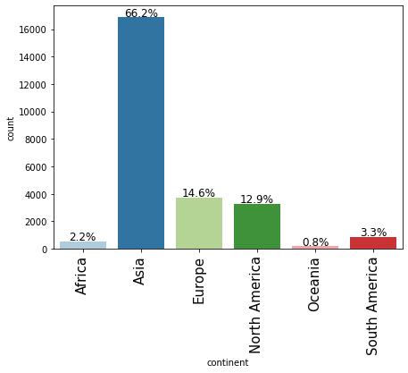

```python
labeled_barplot(data, "continent", perc=True)
```

- Observations
- Asia has the highest applicants followed by Europe and North America

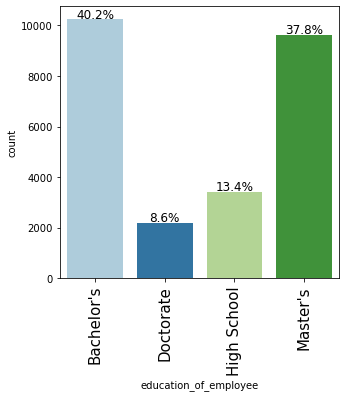

```python
labeled_barplot(data, "education_of_employee", perc=True)
```

- Observations
- Bachelor applicants are highest followed by Master's and High School

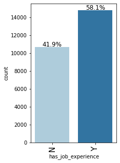

```python
labeled_barplot(data, "has_job_experience", perc=True)
```

- Observations
- 58.1% of applicants have prior job experience. 41.9% of applicants do not have prior job experience

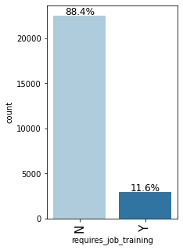

```python
labeled_barplot(data, "requires_job_training", perc=True)
```

- Observations
- 88.4% applicants do not require job training.11.6% of applicants require job training

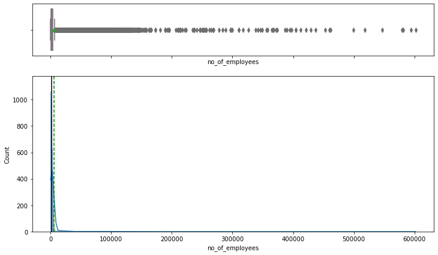

```python
histogram_boxplot(data, "no_of_employees", kde=True)
```

- Observations
- The number of employees variable in this dataset is skewed towards the right
- The mean number of employees is 5667
- We will not treat these outliers as they are not invalid data

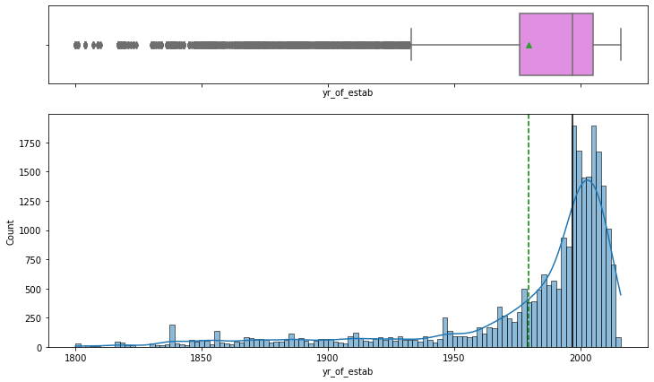

```python
histogram_boxplot(data, "yr_of_estab", kde=True)
```

- Observations
- The yr_of_estab variable is skewed towards the left side
- We will not treat these outliers as they are not invalid data

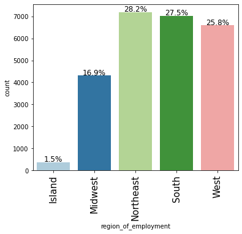

```python
labeled_barplot(data, "region_of_employment", perc=True)
```

- Observations
- The region of employment for the applicants is the highest in the northeast followed by south and west

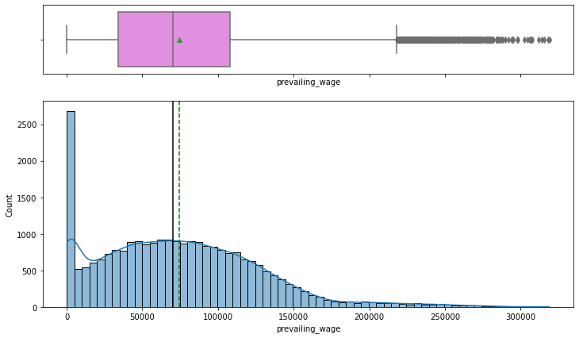

```python
histogram_boxplot(data, "prevailing_wage", kde=True)
```

- Observations
- The prevailing wage has skewness in the right & left sides
- We will not treat these outliers as they are not invalid data

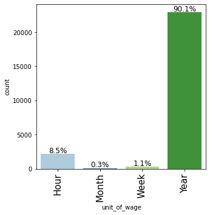

```python
labeled_barplot(data, "unit_of_wage", perc=True)
```

- Observations
- The yearly wages is the highest followed by hourly and weekly

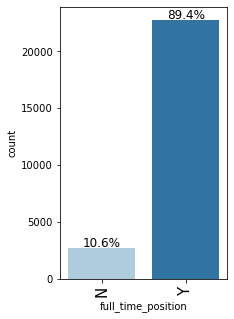

```python
labeled_barplot(data, "full_time_position", perc=True)
```

- Observations
- The full time position type of the employment is 89.4% followed by part time positions that are 10.6%

### Bivariate analysis

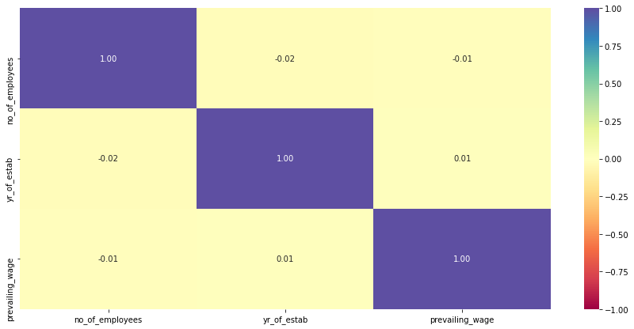

```python
plt.figure(figsize=(15, 7))
sns.heatmap(data.corr(), annot=True, vmin=-1, vmax=1, fmt=".2f", cmap="Spectral")
plt.show()
```

- Observations
- There is no significant correlation between the numerical columns

```python
### Function to plot stacked bar charts for categorical columns
def stacked_plot(x):
    sns.set()
    ## crosstab
    tab1 = pd.crosstab(x, data["salary"], margins=True).sort_values(
        by=" >50K", ascending=False
    )
    print(tab1)
    print("-" * 120)
    ## visualising the cross tab
    tab = pd.crosstab(x, data["salary"], normalize="index").sort_values(
        by=" >50K", ascending=False
    )
    tab.plot(kind="bar", stacked=True, figsize=(17, 7))
    plt.legend(
        loc="lower left",
        frameon=False,
    )
    plt.legend(loc="upper left", bbox_to_anchor=(1, 1))
    plt.show()
```

```python
def stacked_barplot(data, predictor, target):
    """
    Print the category counts and plot a stacked bar chart

    data: dataframe
    predictor: independent variable
    target: target variable
    """
    count = data[predictor].nunique()
    sorter = data[target].value_counts().index[-1]
    tab1 = pd.crosstab(data[predictor], data[target], margins=True).sort_values(
        by=sorter, ascending=False
    )
    print(tab1)
    print("-" * 120)
    tab = pd.crosstab(data[predictor], data[target], normalize="index").sort_values(
        by=sorter, ascending=False
    )
    tab.plot(kind="bar", stacked=True, figsize=(count + 5, 5))
    plt.legend(
        loc="lower left",
        frameon=False,
    )
    plt.legend(loc="upper left", bbox_to_anchor=(1, 1))
    plt.show()
```

- Bivariate analysis to understand that those with higher education may want to travel abroad for a well-paid job. Does education play a role in Visa certification?

```
case_status            Certified  Denied    All
education_of_employee
All                        17018    8462  25480
Bachelor's                  6367    3867  10234
High School                 1164    2256   3420
Master's                    7575    2059   9634
Doctorate                   1912     280   2192
------------------------------------------------------------------------------------------------------------------------
```

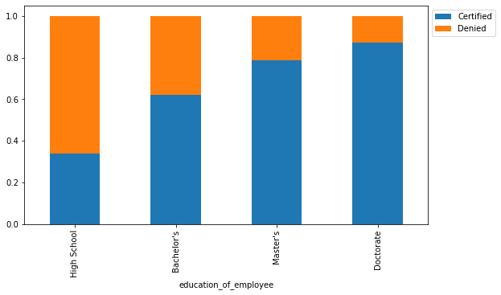

```python
stacked_barplot(data, "education_of_employee", "case_status")
```

- Observations
- Doctorate have the highest chance of visa certification. This education category has the least denial.
- 78% of the applicants with Masters degree get visa certified
- 62% of the applicants with Bachelors degree get visa certified
- Only 34% of the applicants with high school degress get the visa certification. The rate if denial is the higher in this category of education
- Overall Doctorate,Master and Bachelors degree have a good chance of getting visa certified. Education is definitely playing a key role in Visa certification process
- Bivariate analysis to understand how does the visa status vary across different continents?

```
case_status    Certified  Denied    All
continent
All                17018    8462  25480
Asia               11012    5849  16861
North America       2037    1255   3292
Europe              2957     775   3732
South America        493     359    852
Africa               397     154    551
Oceania              122      70    192
------------------------------------------------------------------------------------------------------------------------
```

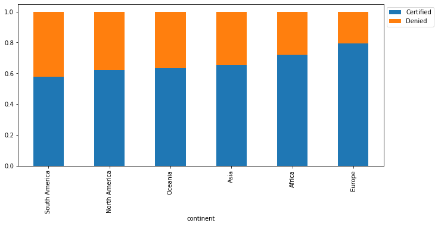

```python
stacked_barplot(data, "continent", "case_status")
```

- Observations
- Asian applicants are the toppers among the continents to get the visa certified followed by Europeans and North Americans
- The South American applicants are the highest among the visa denial. 42% of them get visa denials.
- Bivariate analysis to understand which pay unit is most likely to be certified for a visa

```
case_status   Certified  Denied    All
unit_of_wage
All               17018    8462  25480
Year              16047    6915  22962
Hour                747    1410   2157
Week                169     103    272
Month                55      34     89
------------------------------------------------------------------------------------------------------------------------
```

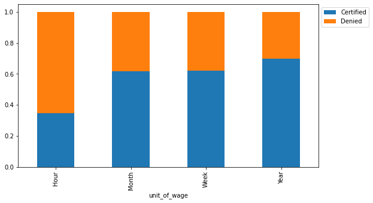

```python
stacked_barplot(data, "unit_of_wage", "case_status")
```

```python
### function to plot distributions wrt target


def distribution_plot_wrt_target(data, predictor, target):

    fig, axs = plt.subplots(2, 2, figsize=(12, 10))

    target_uniq = data[target].unique()

    axs[0, 0].set_title("Distribution of target for target=" + str(target_uniq[0]))
    sns.histplot(
        data=data[data[target] == target_uniq[0]],
        x=predictor,
        kde=True,
        ax=axs[0, 0],
        color="teal",
        stat="density",
    )

    axs[0, 1].set_title("Distribution of target for target=" + str(target_uniq[1]))
    sns.histplot(
        data=data[data[target] == target_uniq[1]],
        x=predictor,
        kde=True,
        ax=axs[0, 1],
        color="orange",
        stat="density",
    )

    axs[1, 0].set_title("Boxplot w.r.t target")
    sns.boxplot(data=data, x=target, y=predictor, ax=axs[1, 0], palette="gist_rainbow")

    axs[1, 1].set_title("Boxplot (without outliers) w.r.t target")
    sns.boxplot(
        data=data,
        x=target,
        y=predictor,
        ax=axs[1, 1],
        showfliers=False,
        palette="gist_rainbow",
    )

    plt.tight_layout()
    plt.show()
```

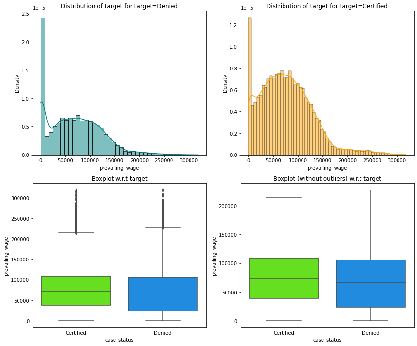

```python
distribution_plot_wrt_target(data, "prevailing_wage", "case_status")
```

- Observations
- Based off the above distribution plot,the prevailing wage has skewness on both certified and denied visa certifications on the left and right side of the distribution
- There are outliers on prevailing wages in both the visa certification categories

```
case_status         Certified  Denied    All
has_job_experience
All                     17018    8462  25480
N                        5994    4684  10678
Y                       11024    3778  14802
------------------------------------------------------------------------------------------------------------------------
```

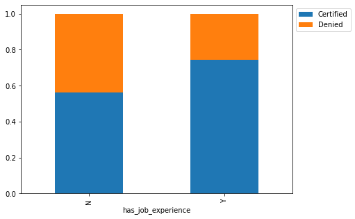

```python
# explore the relationship between job experience and case status
data1 = EasyVisa.copy()
stacked_barplot(data1, "has_job_experience", "case_status")
```

- Observations
- Applicants with job experience have a higher chance of getting certified

## Data Preprocessing

- Missing value treatment (if needed)
- Feature engineering
- Outlier detection and treatment (if needed)
- Preparing data for modeling
- Any other preprocessing steps (if needed)

```python
# Check if there are any null values
data.isnull().sum()
```

```
continent                0
education_of_employee    0
has_job_experience       0
requires_job_training    0
no_of_employees          0
yr_of_estab              0
region_of_employment     0
prevailing_wage          0
unit_of_wage             0
full_time_position       0
case_status              0
dtype: int64
```

- Observations
- No null values found

```python
# Convert the datatype of the case_status variable to numeric
data.replace(to_replace="Certified", value=1, inplace=True)
data.replace(to_replace="Denied", value=0, inplace=True)
data["case_status"] = pd.to_numeric(data["case_status"])
```

```python
# Verify the first 5 rows to check if the case status conversion is complete
data.head()
```

|  | continent | education_of_employee | has_job_experience | requires_job_training | no_of_employees | yr_of_estab | region_of_employment | prevailing_wage | unit_of_wage | full_time_position | case_status |
| --- | --- | --- | --- | --- | --- | --- | --- | --- | --- | --- | --- |
| 0 | Asia | High School | N | N | 14513 | 2007 | West | 592.2029 | Hour | Y | 0 |
| 1 | Asia | Master's | Y | N | 2412 | 2002 | Northeast | 83425.6500 | Year | Y | 1 |
| 2 | Asia | Bachelor's | N | Y | 44444 | 2008 | West | 122996.8600 | Year | Y | 0 |
| 3 | Asia | Bachelor's | N | N | 98 | 1897 | West | 83434.0300 | Year | Y | 0 |
| 4 | Africa | Master's | Y | N | 1082 | 2005 | South | 149907.3900 | Year | Y | 1 |

```python
# Convert object and category variables to dummy variables
data = pd.get_dummies(
    data,
    columns=[
        "continent",
        "education_of_employee",
        "has_job_experience",
        "requires_job_training",
        "region_of_employment",
        "unit_of_wage",
        "full_time_position"
    ],
    drop_first=True,
)
```

```python
# Verify the first 5 rows to check for dummy variable conversion
data.head()
```

|  | no_of_employees | yr_of_estab | prevailing_wage | case_status | continent_Asia | continent_Europe | continent_North America | continent_Oceania | continent_South America | education_of_employee_Doctorate | ... | has_job_experience_Y | requires_job_training_Y | region_of_employment_Midwest | region_of_employment_Northeast | region_of_employment_South | region_of_employment_West | unit_of_wage_Month | unit_of_wage_Week | unit_of_wage_Year | full_time_position_Y |
| --- | --- | --- | --- | --- | --- | --- | --- | --- | --- | --- | --- | --- | --- | --- | --- | --- | --- | --- | --- | --- | --- |
| 0 | 14513 | 2007 | 592.2029 | 0 | 1 | 0 | 0 | 0 | 0 | 0 | ... | 0 | 0 | 0 | 0 | 0 | 1 | 0 | 0 | 0 | 1 |
| 1 | 2412 | 2002 | 83425.6500 | 1 | 1 | 0 | 0 | 0 | 0 | 0 | ... | 1 | 0 | 0 | 1 | 0 | 0 | 0 | 0 | 1 | 1 |
| 2 | 44444 | 2008 | 122996.8600 | 0 | 1 | 0 | 0 | 0 | 0 | 0 | ... | 0 | 1 | 0 | 0 | 0 | 1 | 0 | 0 | 1 | 1 |
| 3 | 98 | 1897 | 83434.0300 | 0 | 1 | 0 | 0 | 0 | 0 | 0 | ... | 0 | 0 | 0 | 0 | 0 | 1 | 0 | 0 | 1 | 1 |
| 4 | 1082 | 2005 | 149907.3900 | 1 | 0 | 0 | 0 | 0 | 0 | 0 | ... | 1 | 0 | 0 | 0 | 1 | 0 | 0 | 0 | 1 | 1 |

5 rows × 22 columns

## EDA

- It is a good idea to explore the data once again after manipulating it.

```python
# Verify the datatype of the dummy variables
data.info()
```

```
<class 'pandas.core.frame.DataFrame'>
RangeIndex: 25480 entries, 0 to 25479
Data columns (total 22 columns):
 #   Column                             Non-Null Count  Dtype
---  ------                             --------------  -----
 0   no_of_employees                    25480 non-null  int64
 1   yr_of_estab                        25480 non-null  int64
 2   prevailing_wage                    25480 non-null  float64
 3   case_status                        25480 non-null  int64
 4   continent_Asia                     25480 non-null  uint8
 5   continent_Europe                   25480 non-null  uint8
 6   continent_North America            25480 non-null  uint8
 7   continent_Oceania                  25480 non-null  uint8
 8   continent_South America            25480 non-null  uint8
 9   education_of_employee_Doctorate    25480 non-null  uint8
 10  education_of_employee_High School  25480 non-null  uint8
 11  education_of_employee_Master's     25480 non-null  uint8
 12  has_job_experience_Y               25480 non-null  uint8
 13  requires_job_training_Y            25480 non-null  uint8
 14  region_of_employment_Midwest       25480 non-null  uint8
 15  region_of_employment_Northeast     25480 non-null  uint8
 16  region_of_employment_South         25480 non-null  uint8
 17  region_of_employment_West          25480 non-null  uint8
 18  unit_of_wage_Month                 25480 non-null  uint8
 19  unit_of_wage_Week                  25480 non-null  uint8
 20  unit_of_wage_Year                  25480 non-null  uint8
 21  full_time_position_Y               25480 non-null  uint8
dtypes: float64(1), int64(3), uint8(18)
memory usage: 1.2 MB
```

```python
data.duplicated().value_counts()
```

```
False    25480
dtype: int64
```

- Observations
- No duplicate values found

## Building bagging and boosting models

### Split the data into train and test sets

```python
# Creating training and test sets
X = data.drop(["case_status"], axis=1)
y = data["case_status"]
```

```python
X_train, X_test, y_train, y_test = train_test_split(X, y, test_size=.30, random_state=1)
```

```python
print("Shape of Training set : ", X_train.shape)
print("Shape of test set : ", X_test.shape)
print("Percentage of classes in training set:")
print(y_train.value_counts(normalize=True))
print("Percentage of classes in test set:")
print(y_test.value_counts(normalize=True))
```

```
Shape of Training set :  (17836, 21)
Shape of test set :  (7644, 21)
Percentage of classes in training set:
1    0.663602
0    0.336398
Name: case_status, dtype: float64
Percentage of classes in test set:
1    0.677917
0    0.322083
Name: case_status, dtype: float64
```

```python
## Function to create confusion matrix
def make_confusion_matrix(model,y_actual,labels=[1, 0]):
    '''
    model : classifier to predict values of X
    y_actual : ground truth

    '''
    y_predict = model.predict(X_test)
    cm=metrics.confusion_matrix( y_actual, y_predict, labels=[0, 1])
    df_cm = pd.DataFrame(cm, index = [i for i in ["Actual - No","Actual - Yes"]],
                  columns = [i for i in ['Predicted - No','Predicted - Yes']])
    group_counts = ["{0:0.0f}".format(value) for value in
                cm.flatten()]
    group_percentages = ["{0:.2%}".format(value) for value in
                         cm.flatten()/np.sum(cm)]
    labels = [f"{v1}\n{v2}" for v1, v2 in
              zip(group_counts,group_percentages)]
    labels = np.asarray(labels).reshape(2,2)
    plt.figure(figsize = (10,7))
    sns.heatmap(df_cm, annot=labels,fmt='')
    plt.ylabel('True label')
    plt.xlabel('Predicted label')
```

```python
##  Function to calculate different metric scores of the model - Accuracy, Recall and Precision
def get_metrics_score(model,flag=True):
    '''
    model : classifier to predict values of X

    '''
    # defining an empty list to store train and test results
    score_list=[]

    #Predicting on train and tests
    pred_train = model.predict(X_train)
    pred_test = model.predict(X_test)

    #Accuracy of the model
    train_acc = model.score(X_train,y_train)
    test_acc = model.score(X_test,y_test)

    #Recall of the model
    train_recall = metrics.recall_score(y_train,pred_train)
    test_recall = metrics.recall_score(y_test,pred_test)

    #Precision of the model
    train_precision = metrics.precision_score(y_train,pred_train)
    test_precision = metrics.precision_score(y_test,pred_test)

    score_list.extend((train_acc,test_acc,train_recall,test_recall,train_precision,test_precision))

    # If the flag is set to True then only the following print statements will be dispayed. The default value is set to True.
    if flag == True:
        print("Accuracy on training set : ",model.score(X_train,y_train))
        print("Accuracy on test set : ",model.score(X_test,y_test))
        print("Recall on training set : ",metrics.recall_score(y_train,pred_train))
        print("Recall on test set : ",metrics.recall_score(y_test,pred_test))
        print("Precision on training set : ",metrics.precision_score(y_train,pred_train))
        print("Precision on test set : ",metrics.precision_score(y_test,pred_test))

    return score_list # returning the list with train and test scores
```

### Bagging Classifier

```python
# bagging_estimator=LogisticRegression(solver="newton-cg",random_state=1)
bagging_estimator=BaggingClassifier(random_state=1)
bagging_estimator.fit(X_train,y_train)
```

```
BaggingClassifier(random_state=1)
```

```python
bagging_estimator.fit(X_train,y_train)
```

```
BaggingClassifier(random_state=1)
```

```python
#Using above defined function to get accuracy, recall and precision on train and test set
bagging_estimator_score=get_metrics_score(bagging_estimator)
```

```
Accuracy on training set :  0.9842453464902444
Accuracy on test set :  0.6962323390894819
Recall on training set :  0.9851301115241635
Recall on test set :  0.773639521420301
Precision on training set :  0.991075223119422
Precision on test set :  0.7772392400155099
```

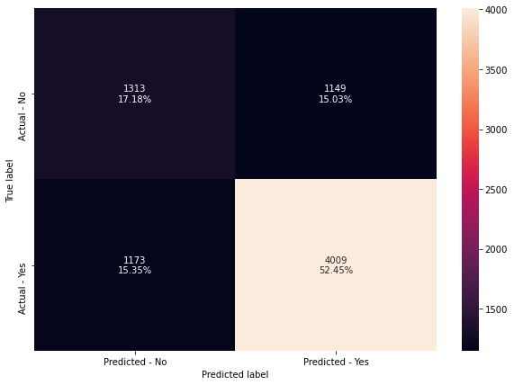

```python
make_confusion_matrix(bagging_estimator,y_test)
```

### Random Forest Classifier

```python
#Train the random forest classifier
rf_estimator=RandomForestClassifier(random_state=1)
rf_estimator.fit(X_train,y_train)
```

```
RandomForestClassifier(random_state=1)
```

```python
#Using above defined function to get accuracy, recall and precision on train and test set
rf_estimator_score=get_metrics_score(rf_estimator)
```

```
Accuracy on training set :  0.999887867234806
Accuracy on test set :  0.7276295133437991
Recall on training set :  1.0
Recall on test set :  0.8344268622153609
Precision on training set :  0.9998310525426592
Precision on test set :  0.779379956741168
```

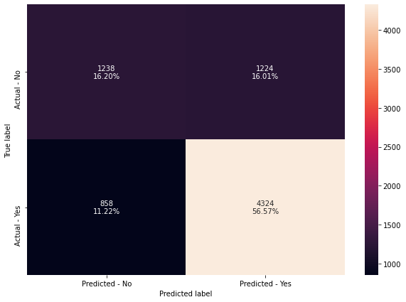

```python
make_confusion_matrix(rf_estimator,y_test)
```

### Boosting

#### AdaBoost Classifier

```python
abc = AdaBoostClassifier(random_state=1)
abc.fit(X_train,y_train)
```

```
AdaBoostClassifier(random_state=1)
```

```python
#Using above defined function to get accuracy, recall and precision on train and test set
abc_score=get_metrics_score(abc)
```

```
Accuracy on training set :  0.7373289975330791
Accuracy on test set :  0.7375719518576661
Recall on training set :  0.8866171003717472
Recall on test set :  0.8855654187572366
Precision on training set :  0.7584013875840139
Precision on test set :  0.7645784738420527
```

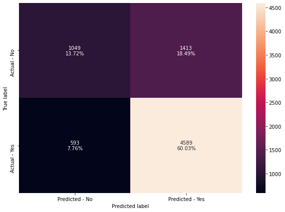

```python
make_confusion_matrix(abc,y_test)
```

### Gradient Boosting Classifier

```python
gbc = GradientBoostingClassifier(random_state=1)
gbc.fit(X_train,y_train)
```

```
GradientBoostingClassifier(random_state=1)
```

```python
gbc_score=get_metrics_score(gbc)
```

```
Accuracy on training set :  0.7562794348508635
Accuracy on test set :  0.7511773940345369
Recall on training set :  0.8755491720175735
Recall on test set :  0.8670397529911231
Precision on training set :  0.7828813175190753
Precision on test set :  0.7874167542937259
```

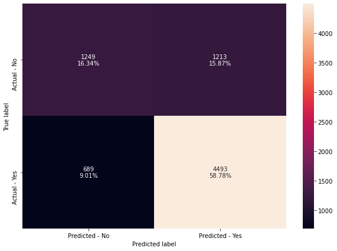

```python
make_confusion_matrix(gbc,y_test)
```